## Climate-smart features

To create climate-smart closures, we prioritized protection of areas with:

1. low levels of **exposure** to climate warming, and
2. high levels of potential **retention** of biodiversity.

We determined these areas using the following metrics:

1. **Relative Climate Exposure (RCE) index**

   $\large RCE(yr^{-1}) = \frac{{\text Slope \hspace{2mm}} (^{\circ}Cyr^{-1} \hspace{2mm} 2050 - 2100)}{{\text Seasonal \hspace{2mm} Range} \hspace{2mm} (^{\circ}C \hspace{2mm} 2015 - 2020)}$
- numerator is the slope of the linear regression of projected mean annual temperatures
- denominator is the current mean seasonal temperature range

Areas with low RCE index values are areas that will be exposed to low levels of warming relative to their current seasonal fluctuations of temperature. Areas of **low RCE index values** are prioritized for selection.

2. **Climate velocity**

   $\large Climate \hspace{2mm} velocity \hspace{2mm} (kmyr^{-1}) = \frac{{\text Slope \hspace{2mm}} (^{\circ}Cyr^{-1} \hspace{2mm} 2050 - 2100)}{{\text Spatial \hspace{2mm} gradient} \hspace{2mm} (^{\circ}Ckm^{-1} \hspace{2mm} 2050 - 2100)}$
- numerator is the slope of the linear regression of projected mean annual temperatures
- denominator is calculated from the vector sum of the latitudinal and longitudinal pairwise differences of the mean temperature at each focal cell using a *3 x 3 neighborhood window*

Areas of slow climate velocity are areas that are more likely to retain their current environmental conditions and consequentially, their biodiversity. Areas of **slow climate velocity** are prioritized for selection.

The temperatures used to calculate the aforementioned metrics were derived from 12 Global Circulation Models (GCMs) from the Couple Model Intercomparison Project Phase 6 (CMIP6; https://esgf-node.llnl.gov). The GCMs are under these three climate scenarios:

1. SSP1-2.6: optimistic scenario
2. SSP2-4.5: intermediate scenario
3. SSP5-8.5: pessimistic scenario

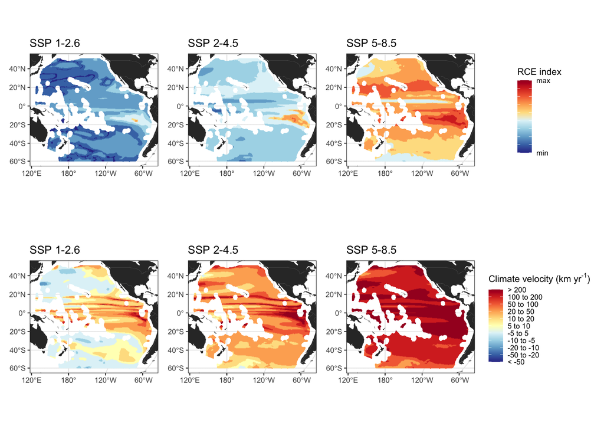

We also tested for the correlation of the climate metrics across different climate scenarios. We used **Spearman Correlation** since the distribution of these metrics are right-skewed, and their Shapiro-Wilk tests are p < 0.05.

RCE and velocity calculated for the same scenario are positively correlated (> 0.5), which could suggest that we can do with just using one of the two metrics. Correlations of climate metrics between scenarios are also positively correlated (> 0.3), with velocity showing higher correlation between metrics than RCE is. For both climate velocity and RCE, SSP 2-4.5 and SSP5-8.5 are also more positively correlated.

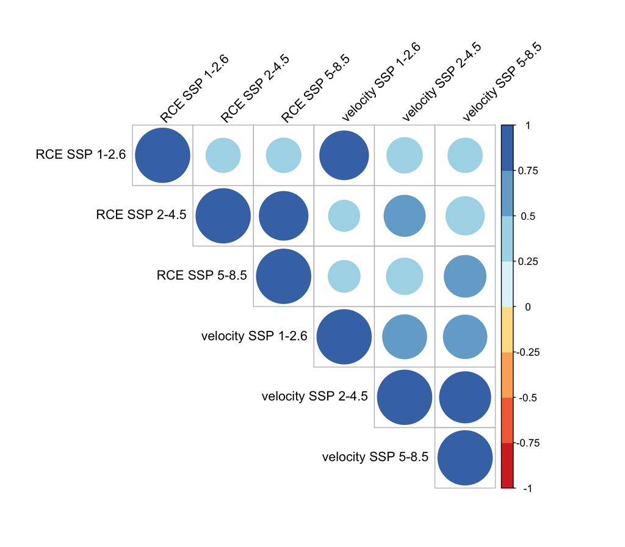